# Portfolio - Martin Chan

A collection of things that I’ve built and shipped - packages, small web apps, and the odd game. Most of them started as tools for my own use, and all of them are open source.

## My packages

I’ve authored several R packages, which are all available on [GitHub](https://www.github.com/martinctc):

R

[figure not shown]

surveytoolbox

Tidy support functions for survey analysis.

R📈tstoolbox

Useful tools for time series analysis in R.

R

[figure not shown]

rwa

Perform a Relative Weights Analysis in R.

R📝textworks

Save time working with survey and text data!

R🗺zipcodes

US zip codes database for R.

R⚙modeltoolbox

Convenience functions for building models in R.

R

[figure not shown]

gpxtoolbox

Tools for analysing and visualising GPX files.

R

[figure not shown]

parallaxr

Generate a parallax scroll document in R with YAML and Markdown.

R

[figure not shown]

devtoolbox

Tools for the R developer.

R

[figure not shown]

mschart2

Experimental add-on to {mschart} with native Office chart features.

R

[figure not shown]

hkdatasets

An R data package containing datasets related to Hong Kong.

Most of these packages were to some extent “by-products” of the analysis that I’ve been doing for the last couple of years, which I decided would have greater value developed into packages.

In addition, I maintain the following packages as part of my work with Microsoft Viva Insights:

R

[figure not shown]

vivainsights

Analyze and visualize Viva Insights data in R.

Python

[figure not shown]

vivainsights-py

Analyze and visualize Viva Insights data in Python.

R

[figure not shown]

wpa

Analyze and visualize Microsoft Workplace Analytics data in R.

If you have any comments or questions about these packages, please get in touch - any feedback would be valuable!

## Vibe-coded projects

Alongside R packages, I’ve recently been building small web apps and tools through “vibe coding” — quick, exploratory builds where I use AI-assisted development to turn an idea into a working tool as directly as possible. These are typically self-contained, browser-based, and built for a specific real-world need of mine.

Python

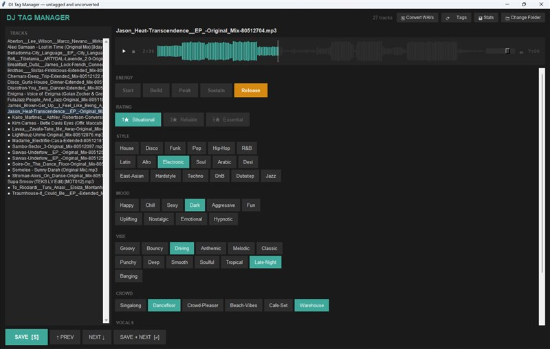

A local Python app for tagging and organising tracks, designed for DJ workflows.

TypeScript

[figure not shown]

Tri Harder

An AI-powered triathlon coaching app.

TypeScript

[figure not shown]

Wrava

A local-first writing app that tracks and analyses your writing activity.

TypeScript

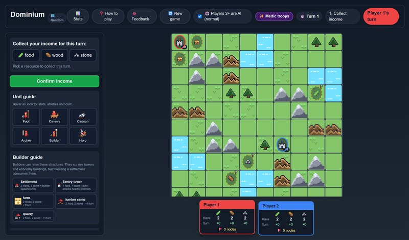

Dominium

A turn-based strategy game for 2 to 4 players, playable in the browser.

Python

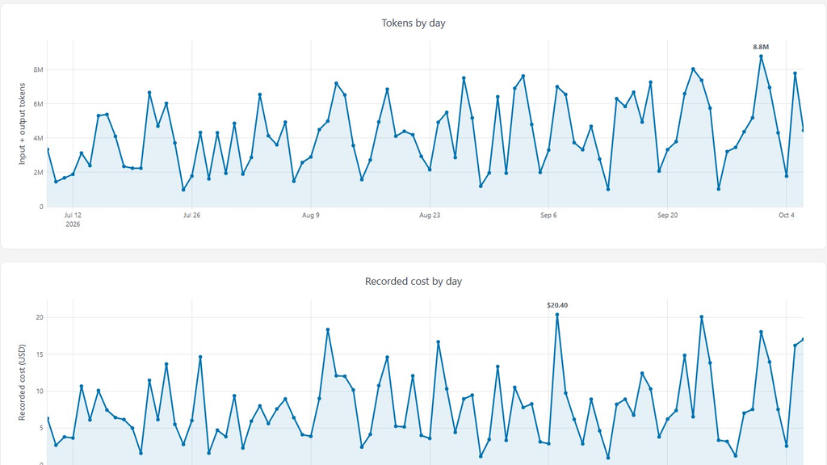

OpenCode Dashboard

A local, read-only dashboard for exploring your OpenCode token usage.

TypeScript

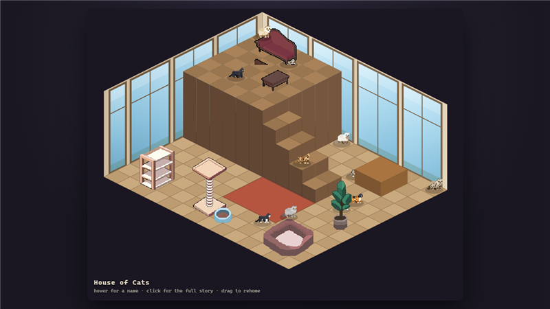

House of Cats

An experimental isometric 2.5D browser scene with pixel-art cats.

JS🚲Bike Routes

A curated collection of cycling routes, with maps, elevation profiles and GPX downloads.

JS📝ds-quiz

A single-page assessment tool for data science knowledge.

For a closer look at each of these projects, I’ve written up the ideas and thinking behind them on the vibe-coded projects page.

## Blogs

On this same site you can find my blog, where I write about things related to #rstats and data science. I contribute my blogs to [r-bloggers](https://www.r-bloggers.com/), [R Craft](https://www.r-craft.org/), and [R Weekly](https://rweekly.org), which you can find as an example two of my blogs featured in the [2019 Week 17 update](https://rweekly.org/2019-17.html) on R Weekly. My post on the [state of R artefacts](https://martinctc.github.io/blog/a-short-essay-on-duplicated-r-artefacts/) is also selected as the highlight post of [2019 Week 27](https://rweekly.org/2019-27.html) on R Weekly.

### Highlight posts

- [RStudio Projects and Working Directories: A Beginner’s Guide](https://martinctc.github.io/blog/rstudio-projects-and-working-directories-a-beginner%27s-guide/) - a starter guide on setting up effective, collaboration-friendly directories - a must read for beginners in R. Special thanks to Chu Kyoyoung for translating this post into [Korean](https://chukycheese.github.io/data%20science/rstudio-project-and-working-directories/).
- [Using data.table with magrittr pipes: best of both worlds](https://martinctc.github.io/blog/using-data.table-with-magrittr-pipes-best-of-both-worlds/) - a post on combining the strengths of the wildly popular **tidyverse** and the blazing fast **data.table** packages
- [LondonR: Hadley Wickham & tidyverse’s greatest hits](https://martinctc.github.io/blog/londonr-hadley-wickham-and-tidyverse-greatest-hits/) - a post covering the highlights of Hadley Wickham’s presentation at LondonR in August 2019.

## EARL Conference 2018

*Enterprise Applications of the R Language Conference (London)*

[figure not shown]

I presented at the EARL Conference 2018 on the challenges of using R for market research, and outlining some of the packages and approaches that help overcome these challenges.

Check out my blog on using R for market research and strategy planning below:

[Swiss Army Knife for Strategy Planning](http://www.rainmakerscsi.com/blog/swiss-army-knife-strategy-planning)

## Interview with Jonathan Ng

*A YouTube Interview on R, Data Science, and Market Research*

[Jonathan Ng](https://datastrategywithjonathan.com/) is a best-selling instructor and Data Scientist who interviewed me on how I use R in a market research and consulting environment, and my personal journey from Excel to R. Check out the full interview here:

[video not shown]